# examples_which_spirolateral

If the turn angle is $\theta=60^{\circ}$ and the maximum segment length is $n=14$, then which spirolateral is created?

You can use this tool:

https://artockthedino.github.io/pbl/spirolateral/spirolateral_generator.html

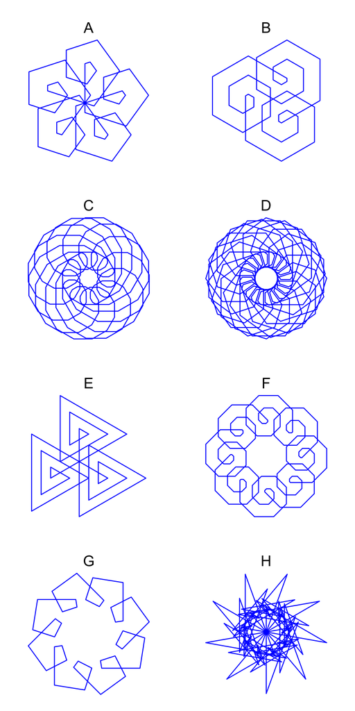

ABCDEFGH

The correct answer is B.

Below I've listed the parameters used to generate all patterns:

- A:
  - Turn angle = 72
  - Count max = 9

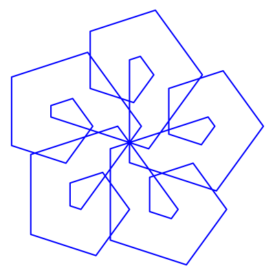

- B:
  - Turn angle = 60
  - Count max = 14

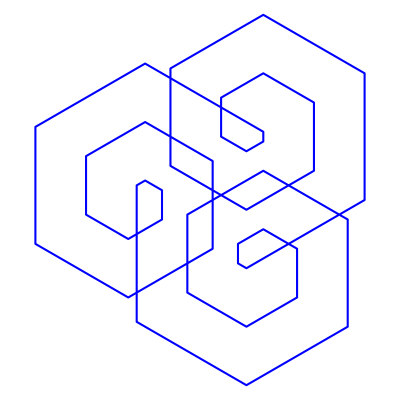

- C:
  - Turn angle = 30
  - Count max = 17

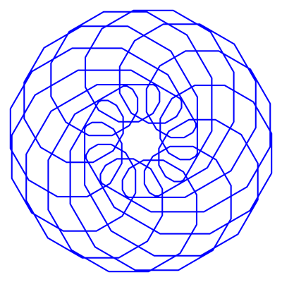

- D:
  - Turn angle = 54
  - Count max = 9

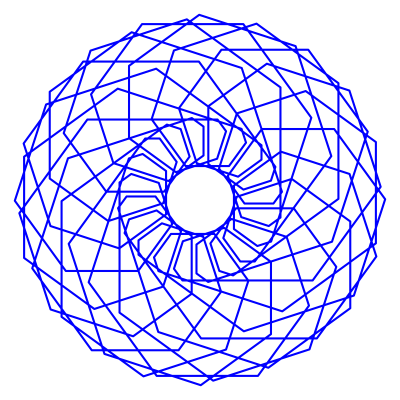

- E:
  - Turn angle = 120
  - Count max = 8

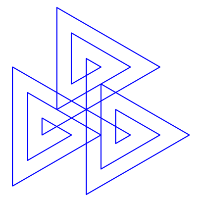

- F:
  - Turn angle = 45
  - Count max = 17

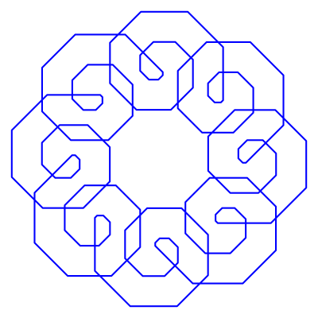

- G:
  - Turn angle = 81
  - Count max = 5

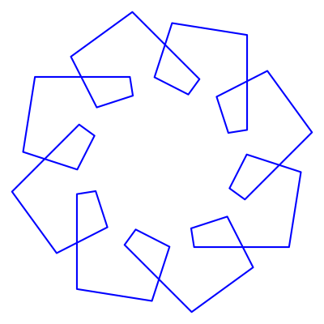

- H:
  - Turn angle = 160
  - Count max = 8

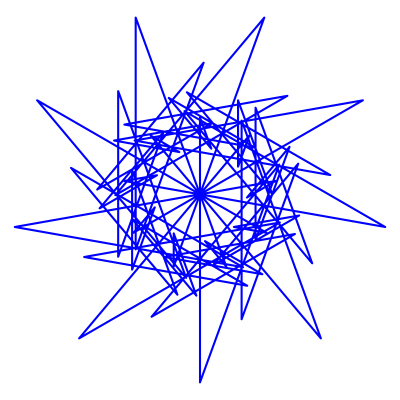

Let's say you want to make a [spirolateral](https://en.wikipedia.org/wiki/Spirolateral).

If the turn angle is $\theta=90^{\circ}$ and the maximum segment length is $n=9$, then which spirolateral is created?

You can use this tool:

https://artockthedino.github.io/pbl/spirolateral/spirolateral_generator.html

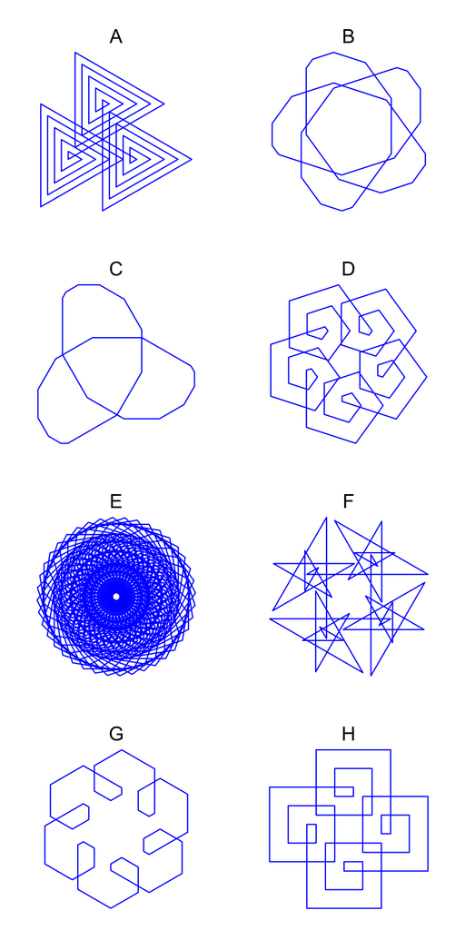

ABCDEFGH

The correct answer is H.

- A:
  - Turn angle = 120
  - Count max = 14

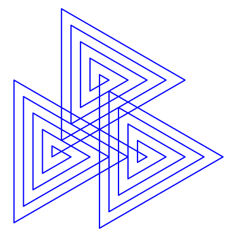

- B:
  - Turn angle = 36
  - Count max = 6

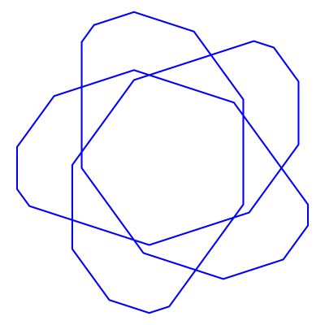

- C:
  - Turn angle = 30
  - Count max = 8

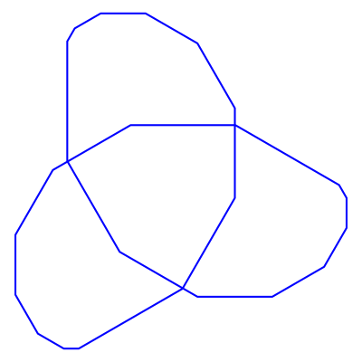

- D:
  - Turn angle = 72
  - Count max = 11

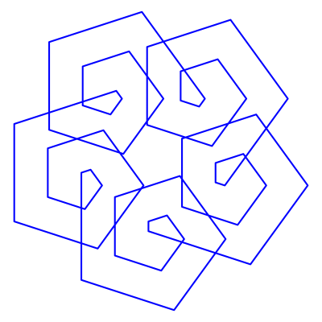

- E:
  - Turn angle = 63
  - Count max = 19

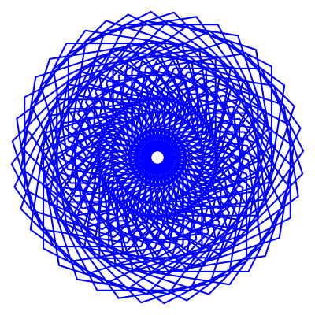

- F:
  - Turn angle = 150
  - Count max = 9

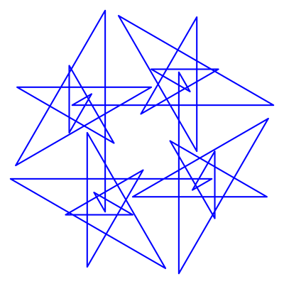

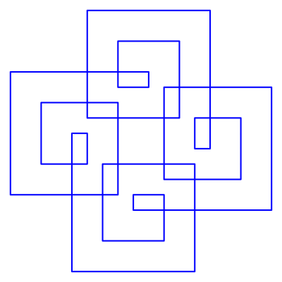

Let's say you want to make a [spirolateral](https://en.wikipedia.org/wiki/Spirolateral).

If the turn angle is $\theta=45^{\circ}$ and the maximum segment length is $n=7$, then which spirolateral is created?

You can use this tool:

https://artockthedino.github.io/pbl/spirolateral/spirolateral_generator.html

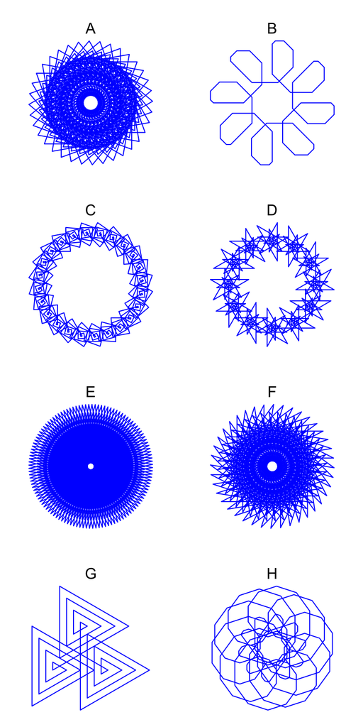

ABCDEFGH

The correct answer is B.

Below I've listed the parameters used to generate all patterns:

- A:
  - Turn angle = 110
  - Count max = 17

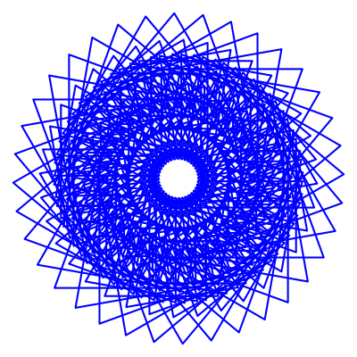

- B:
  - Turn angle = 45
  - Count max = 7

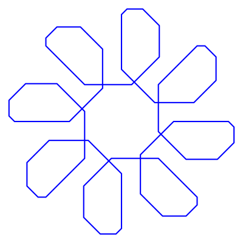

- C:
  - Turn angle = 95
  - Count max = 15

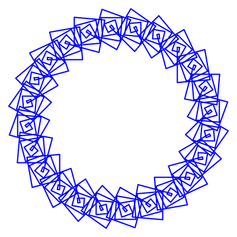

- D:
  - Turn angle = 150
  - Count max = 17

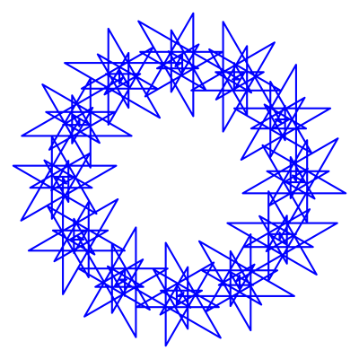

- E:
  - Turn angle = 159
  - Count max = 19

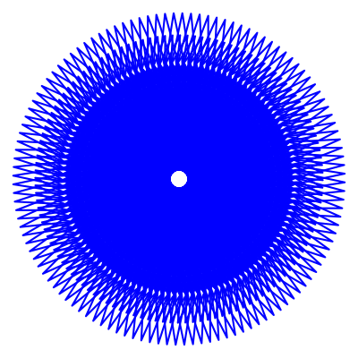

- F:
  - Turn angle = 153
  - Count max = 11

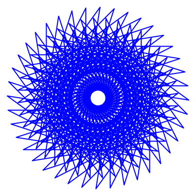

- G:
  - Turn angle = 120
  - Count max = 11

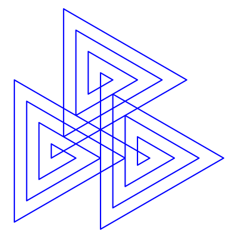

- H:
  - Turn angle = 36
  - Count max = 17

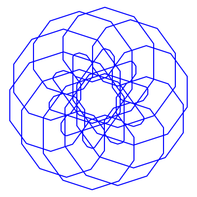

Let's say you want to make a [spirolateral](https://en.wikipedia.org/wiki/Spirolateral).

If the turn angle is $\theta=45^{\circ}$ and the maximum segment length is $n=18$, then which spirolateral is created?

You can use this tool:

https://artockthedino.github.io/pbl/spirolateral/spirolateral_generator.html

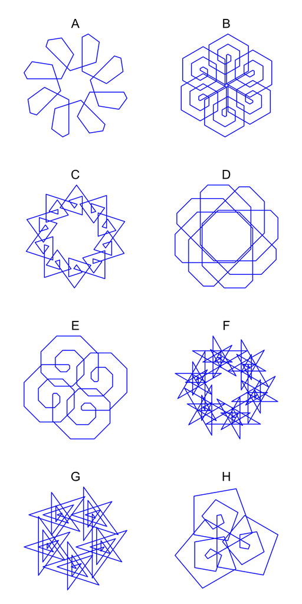

ABCDEFGH

The correct answer is E.

Below I've listed the parameters used to generate all patterns:

- A:
  - Turn angle = 63
  - Count max = 5

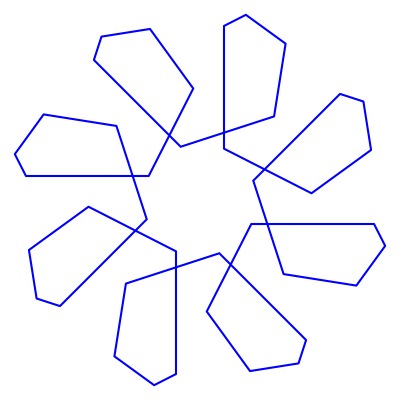

- B:
  - Turn angle = 60
  - Count max = 17

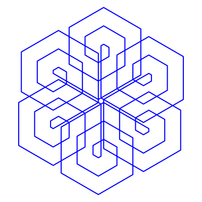

- C:
  - Turn angle = 108
  - Count max = 7

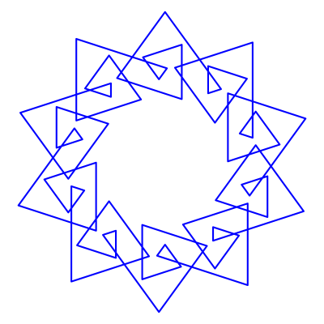

- D:
  - Turn angle = 45
  - Count max = 5

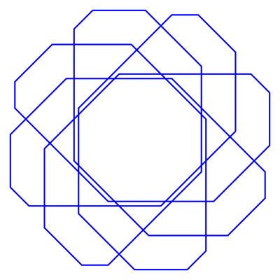

- E:
  - Turn angle = 45
  - Count max = 18

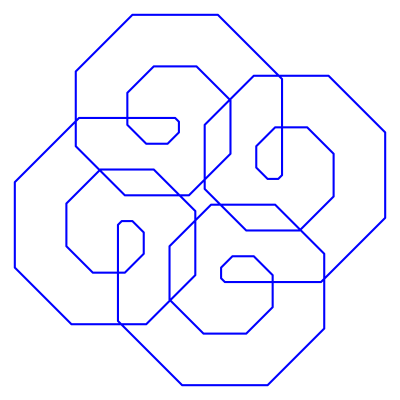

- F:
  - Turn angle = 150
  - Count max = 14

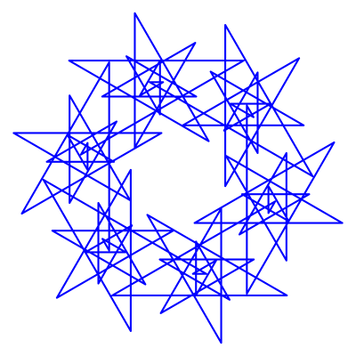

- G:
  - Turn angle = 144
  - Count max = 12

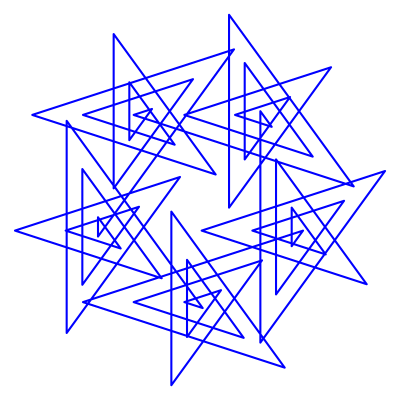

- H:
  - Turn angle = 80
  - Count max = 12

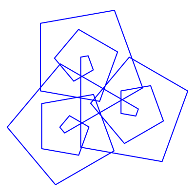

Let's say you want to make a [spirolateral](https://en.wikipedia.org/wiki/Spirolateral).

If the turn angle is $\theta=30^{\circ}$ and the maximum segment length is $n=17$, then which spirolateral is created?

You can use this tool:

https://artockthedino.github.io/pbl/spirolateral/spirolateral_generator.html

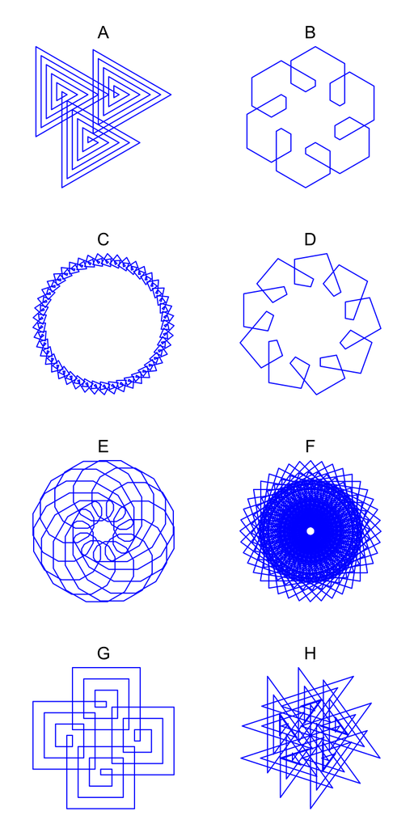

ABCDEFGH

The correct answer is E.

Below I've listed the parameters used to generate all patterns:

- A:
  - Turn angle = 120
  - Count max = 16

[figure not shown]

- B:
  - Turn angle = 60
  - Count max = 7
- C:
  - Turn angle = 104
  - Count max = 7

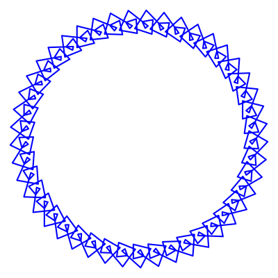

- D:
  - Turn angle = 80
  - Count max = 5

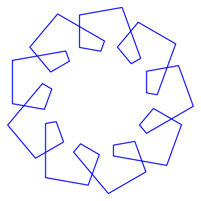

- E:
  - Turn angle = 30
  - Count max = 17

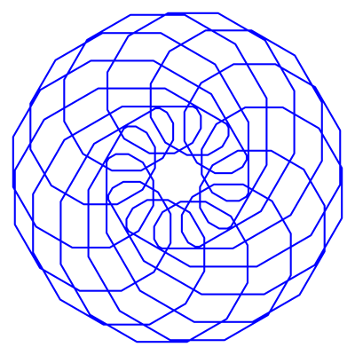

- F:
  - Turn angle = 99
  - Count max = 17

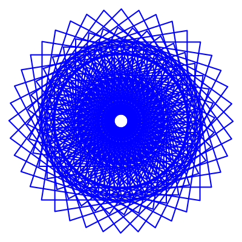

- G:
  - Turn angle = 90
  - Count max = 13

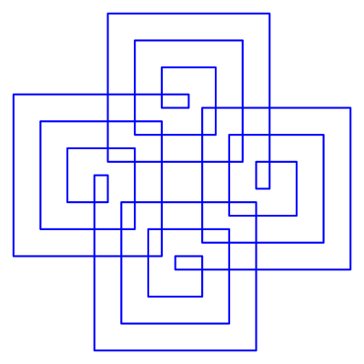

- H:
  - Turn angle = 144
  - Count max = 14

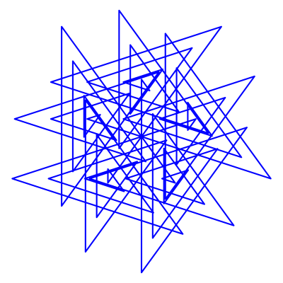

Let's say you want to make a [spirolateral](https://en.wikipedia.org/wiki/Spirolateral).

If the turn angle is $\theta=150^{\circ}$ and the maximum segment length is $n=19$, then which spirolateral is created?

You can use this tool:

https://artockthedino.github.io/pbl/spirolateral/spirolateral_generator.html

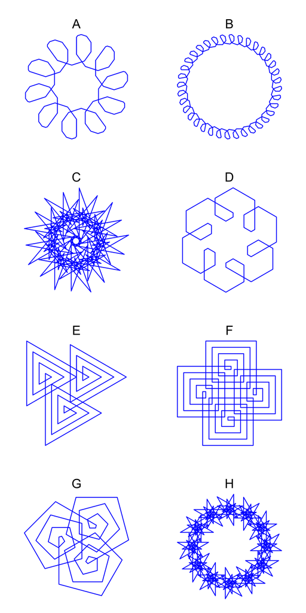

ABCDEFGH

The correct answer is H.

Below I've listed the parameters used to generate all patterns:

- A:
  - Turn angle = 36
  - Count max = 9

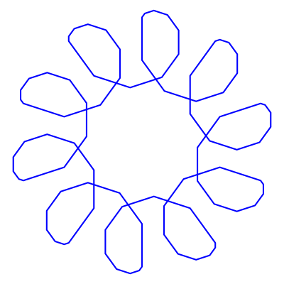

- B:
  - Turn angle = 50
  - Count max = 7

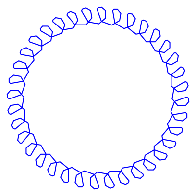

- C:
  - Turn angle = 160
  - Count max = 14

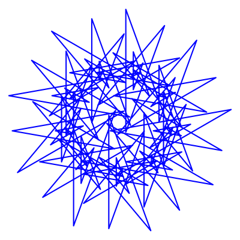

- D:
  - Turn angle = 60
  - Count max = 7
- E:
  - Turn angle = 120
  - Count max = 10

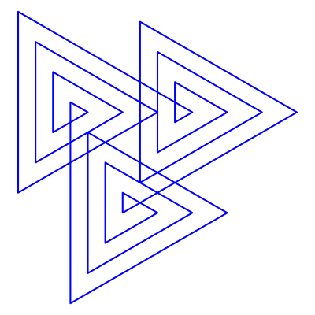

- F:
  - Turn angle = 90
  - Count max = 17

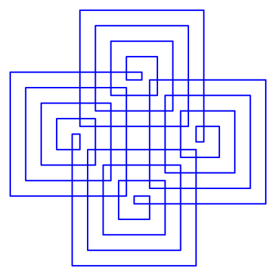

- G:
  - Turn angle = 75
  - Count max = 16

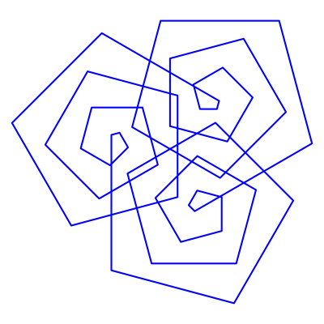

- H:
  - Turn angle = 150
  - Count max = 19

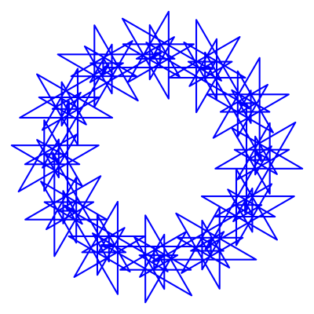

Let's say you want to make a [spirolateral](https://en.wikipedia.org/wiki/Spirolateral).

If the turn angle is $\theta=36^{\circ}$ and the maximum segment length is $n=12$, then which spirolateral is created?